# automatization_notebook

2023-12-24

# Чтение данных

В вашем варианте нужно использовать датасеты cardio_train_big или cardio_train_not_too_big.

```r
# Чтение данных
cardio_train_big <- read_delim("data/raw/cardio_train_big.csv", delim = ";")
```

# Выведите общее описание данных

```r
# Общее описание данных
summary(cardio_train_big)
```

```
##        id             age            gender         height
##  Min.   :    0   Min.   :10798   Min.   :1.00   Min.   : 55.0
##  1st Qu.:25007   1st Qu.:17664   1st Qu.:1.00   1st Qu.:159.0
##  Median :50002   Median :19703   Median :1.00   Median :165.0
##  Mean   :49972   Mean   :19469   Mean   :1.35   Mean   :164.4
##  3rd Qu.:74889   3rd Qu.:21327   3rd Qu.:2.00   3rd Qu.:170.0
##  Max.   :99999   Max.   :23713   Max.   :2.00   Max.   :250.0
##      weight           ap_hi             ap_lo           cholesterol
##  Min.   : 10.00   Min.   : -150.0   Min.   :  -70.00   Min.   :1.000
##  1st Qu.: 65.00   1st Qu.:  120.0   1st Qu.:   80.00   1st Qu.:1.000
##  Median : 72.00   Median :  120.0   Median :   80.00   Median :1.000
##  Mean   : 74.21   Mean   :  128.8   Mean   :   96.63   Mean   :1.367
##  3rd Qu.: 82.00   3rd Qu.:  140.0   3rd Qu.:   90.00   3rd Qu.:2.000
##  Max.   :200.00   Max.   :16020.0   Max.   :11000.00   Max.   :3.000
##       gluc           smoke              alco             active
##  Min.   :1.000   Min.   :0.00000   Min.   :0.00000   Min.   :0.0000
##  1st Qu.:1.000   1st Qu.:0.00000   1st Qu.:0.00000   1st Qu.:1.0000
##  Median :1.000   Median :0.00000   Median :0.00000   Median :1.0000
##  Mean   :1.226   Mean   :0.08813   Mean   :0.05377   Mean   :0.8037
##  3rd Qu.:1.000   3rd Qu.:0.00000   3rd Qu.:0.00000   3rd Qu.:1.0000
##  Max.   :3.000   Max.   :1.00000   Max.   :1.00000   Max.   :1.0000
##      cardio
##  Min.   :0.0000
##  1st Qu.:0.0000
##  Median :0.0000
##  Mean   :0.4997
##  3rd Qu.:1.0000
##  Max.   :1.0000
```

```r
# Структура данных
str(cardio_train_big)
```

```
## spc_tbl_ [70,000 × 13] (S3: spec_tbl_df/tbl_df/tbl/data.frame)
##  $ id         : num [1:70000] 0 1 2 3 4 8 9 12 13 14 ...
##  $ age        : num [1:70000] 18393 20228 18857 17623 17474 ...
##  $ gender     : num [1:70000] 2 1 1 2 1 1 1 2 1 1 ...
##  $ height     : num [1:70000] 168 156 165 169 156 151 157 178 158 164 ...
##  $ weight     : num [1:70000] 62 85 64 82 56 67 93 95 71 68 ...
##  $ ap_hi      : num [1:70000] 110 140 130 150 100 120 130 130 110 110 ...
##  $ ap_lo      : num [1:70000] 80 90 70 100 60 80 80 90 70 60 ...
##  $ cholesterol: num [1:70000] 1 3 3 1 1 2 3 3 1 1 ...
##  $ gluc       : num [1:70000] 1 1 1 1 1 2 1 3 1 1 ...
##  $ smoke      : num [1:70000] 0 0 0 0 0 0 0 0 0 0 ...
##  $ alco       : num [1:70000] 0 0 0 0 0 0 0 0 0 0 ...
##  $ active     : num [1:70000] 1 1 0 1 0 0 1 1 1 0 ...
##  $ cardio     : num [1:70000] 0 1 1 1 0 0 0 1 0 0 ...
##  - attr(*, "spec")=
##   .. cols(
##   ..   id = col_double(),
##   ..   age = col_double(),
##   ..   gender = col_double(),
##   ..   height = col_double(),
##   ..   weight = col_double(),
##   ..   ap_hi = col_double(),
##   ..   ap_lo = col_double(),
##   ..   cholesterol = col_double(),
##   ..   gluc = col_double(),
##   ..   smoke = col_double(),
##   ..   alco = col_double(),
##   ..   active = col_double(),
##   ..   cardio = col_double()
##   .. )
##  - attr(*, "problems")=<externalptr>
```

# Очистка данных

1. Уберите переменные, в которых пропущенных значений больше 20% или уберите субъектов со слишком большим количеством пропущенных значений. Или совместите оба варианта. Напишите обоснование, почему вы выбрали тот или иной вариант:

1.1 Проверяем наличие NA:

```r
# Подсчет пропущенных значений для каждой переменной
missing_values <- sapply(cardio_train_big, function(x) sum(is.na(x)))

# Процент пропущенных значений для каждой переменной
missing_percentage <- missing_values / nrow(cardio_train_big) * 100

# Вывод процентов пропущенных значений
missing_percentage
```

```
##          id         age      gender      height      weight       ap_hi
##           0           0           0           0           0           0
##       ap_lo cholesterol        gluc       smoke        alco      active
##           0           0           0           0           0           0
##      cardio
##           0
```

```r
# Определение переменных с более чем 20% пропущенных значений
vars_to_remove <- names(missing_percentage[missing_percentage > 20])

# Вывод переменных, которые необходимо удалить (если таковые имеются)
vars_to_remove
```

```
## character(0)
```

NA отсутствуют.

1.2 Возможно пропущенные значения записану нулями, проверим:

```r
# Подсчет нулевых значений для каждой переменной
zero_values <- sapply(cardio_train_big, function(x) sum(x == 0))

# Процент нулевых значений для каждой переменной
zero_percentage <- zero_values / nrow(cardio_train_big) * 100

# Вывод процентов нулевых значений
zero_percentage
```

```
##           id          age       gender       height       weight        ap_hi
##  0.001428571  0.000000000  0.000000000  0.000000000  0.000000000  0.000000000
##        ap_lo  cholesterol         gluc        smoke         alco       active
##  0.030000000  0.000000000  0.000000000 91.187142857 94.622857143 19.627142857
##       cardio
## 50.030000000
```

Нулевые значения есть в id, ap_lo, smoke, alco, active и cardio. В id, smoke, alco, active и cardio это ожидаемые значения, удалять которые не будем.

А в ap_lo заменим нули на NA:

```r
# Замена нулей на NA
cardio_train_big$ap_lo[cardio_train_big$ap_lo == 0] <- NA
```

*Почему заменяем на NA, а не удаляем?*

Поддержание целостности данных: замена нулей на NA позволяет сохранить остальные данные в строке, которые могут быть полезны для анализа. Удаление всей строки может привести к потере ценной информации по другим переменным.

Гибкость в дальнейшей обработке: обозначение нулевых значений как NA дает больше возможностей для их последующей обработки, например, замены на среднее или медианное значение или использования методов импутации при необходимости.

*Когда пропущенных значений в датасете более 20%, можно предпринять следующие действия:*

*Удалить переменные: если пропущенных значений слишком много (например, более 20%), и это может существенно исказить результаты анализа, стоит рассмотреть возможность удаления таких переменных.

*Удалить строки: если пропущенные значения сосредоточены в небольшом числе строк, их можно удалить.

*Импутация: пропущенные значения можно заменить средними, медианными или модальными значениями, или использовать более сложные методы импутации.

*Создание индикаторных переменных: для каждой переменной с большим количеством пропущенных значений возможно создание дополнительной индикаторной переменной, которая показывает, было ли пропущено значение в этой переменной.

*Моделирование пропущенных значений: использование статистических моделей (например, регрессионных моделей) для предсказания пропущенных значений на основе других переменных в наборе данных.

*Анализ чувствительности: проведение анализа с разными методами обработки пропущенных данных, чтобы понять, насколько результаты чувствительны к способу обработки пропущенных значений.

Выбор подхода зависит от контекста данных, целей исследования и значимости пропущенных переменных для анализа.

2. Переименуйте переменные в человекочитаемый вид (что делать с пробелами в названиях?);

Пробелов в названиях быть не должно. Названия переменных записываются через подчеркивание или с большой буквы.

```r
cardio_train_big <- cardio_train_big %>%
  rename(
    patient_id = id,
    age_days = age,
    patient_gender = gender,
    patient_height_cm = height,
    patient_weight_kg = weight,
    systolic_bp = ap_hi,
    diastolic_bp = ap_lo,
    cholesterol_level = cholesterol,
    glucose_level = gluc,
    is_smoker = smoke,
    consumes_alcohol = alco,
    is_active = active,
    has_cardio_disease = cardio
  )
```

3. В соответствии с описанием данных приведите переменные к нужному типу (numeric или factor);

```r
cardio_train_big <- cardio_train_big %>%
  mutate_at(vars(age_days, patient_height_cm, patient_weight_kg, systolic_bp, diastolic_bp), as.numeric) %>%
  mutate_at(vars(patient_gender, is_smoker, consumes_alcohol, is_active, has_cardio_disease), as.factor) %>%
  mutate(
    cholesterol_level = factor(cholesterol_level, levels = c(1, 2, 3), labels = c("normal", "above_normal", "well_above_normal")),
    glucose_level = factor(glucose_level, levels = c(1, 2, 3), labels = c("normal", "above_normal", "well_above_normal"))
  )
```

4. Отсортируйте данные по возрасту по убыванию;

```r
cardio_train_big <- cardio_train_big %>%
  arrange(desc(age_days))
```

5. Сохраните в файл outliers.csv субъектов, которые являются выбросами (например, по правилу трёх сигм) — это необязательное задание со звёздочкой;

```r
# Установка пороговых значений для артериального давления (т.к. правильно трех сигм не позволяет удалить все биологически невозможные значения из датасета)

lower_systolic_threshold <- 60
upper_systolic_threshold <- 230
lower_diastolic_threshold <- 30
upper_diastolic_threshold <- 150

# Предварительное вычисление средних и стандартных отклонений для других переменных
mean_age_days <- mean(cardio_train_big$age_days, na.rm = TRUE)
sd_age_days <- sd(cardio_train_big$age_days, na.rm = TRUE)
mean_patient_height_cm <- mean(cardio_train_big$patient_height_cm, na.rm = TRUE)
sd_patient_height_cm <- sd(cardio_train_big$patient_height_cm, na.rm = TRUE)
mean_patient_weight_kg <- mean(cardio_train_big$patient_weight_kg, na.rm = TRUE)
sd_patient_weight_kg <- sd(cardio_train_big$patient_weight_kg, na.rm = TRUE)

# Фильтрация выбросов
outliers <- cardio_train_big %>%
  filter(
    age_days < (mean_age_days - 3 * sd_age_days) | age_days > (mean_age_days + 3 * sd_age_days) |
    patient_height_cm < (mean_patient_height_cm - 3 * sd_patient_height_cm) | patient_height_cm > (mean_patient_height_cm + 3 * sd_patient_height_cm) |
    patient_weight_kg < (mean_patient_weight_kg - 3 * sd_patient_weight_kg) | patient_weight_kg > (mean_patient_weight_kg + 3 * sd_patient_weight_kg) |
    systolic_bp < lower_systolic_threshold | systolic_bp > upper_systolic_threshold |
    diastolic_bp < lower_diastolic_threshold | diastolic_bp > upper_diastolic_threshold
  )

# Сохранение выбросов в файл в подкаталоге 'data'
write.csv(outliers, "data/outliers.csv", row.names = FALSE)
```

6. Присвойте получившийся датасет переменной “cleaned_data”.

```r
cleaned_data <- cardio_train_big %>%
  anti_join(outliers, by = "patient_id")

# Сохранение в файл в подкаталоге 'data'
write.csv(cleaned_data, "data/cleaned_data.csv", row.names = FALSE)
```

# Сколько осталось переменных?

```r
# Количество переменных в датасете cleaned_data
num_variables <- ncol(cleaned_data)

# Вывод количества переменных
num_variables
```

```
## [1] 13
```

# Сколько осталось случаев?

```r
# Количество случаев (строк) в датасете cleaned_data
num_cases <- nrow(cleaned_data)

# Вывод количества случаев
num_cases
```

```
## [1] 67827
```

# Есть ли в данных идентичные строки?

```r
# Проверка на наличие идентичных строк в данных
any_duplicated <- any(duplicated(cleaned_data))

# Вывод результата
any_duplicated
```

```
## [1] FALSE
```

# Сколько всего переменных с пропущенными значениями в данных и сколько пропущенных точек в каждой такой переменной?

```r
# Подсчет пропущенных значений в каждой переменной
missing_values_count <- sapply(cleaned_data, function(x) sum(is.na(x)))

# Отфильтровывание переменных без пропущенных значений
missing_values_count <- missing_values_count[missing_values_count > 0]

# Количество переменных с пропущенными значениями
num_vars_with_missing_values <- length(missing_values_count)

# Вывод количества переменных с пропущенными значениями и количества пропущенных значений в каждой такой переменной
num_vars_with_missing_values
```

```
## [1] 1
```

```r
missing_values_count
```

```
## diastolic_bp
##           12
```

# Описательные статистики

## Количественные переменные

1. Рассчитайте для всех количественных переменных для каждой группы (наличие или отсутствие сердечно-сосудистых заболеваний):

1.1) Количество значений;

```r
# Расчет количества значений для количественных переменных в каждой группе
descriptive_stats_count <- cleaned_data %>%
  group_by(has_cardio_disease) %>%
  summarise(
    count_age_days = n(),
    count_patient_height_cm = n(),
    count_patient_weight_kg = n(),
    count_systolic_bp = n(),
    count_diastolic_bp = n()
  )

# Вывод результатов
descriptive_stats_count
```

| has_cardio_disease | count_age_days | count_patient_height_cm | count_patient_weight_kg | count_systolic_bp | count_diastolic_bp |
| --- | --- | --- | --- | --- | --- |
| 0 | 34406 | 34406 | 34406 | 34406 | 34406 |
| 1 | 33421 | 33421 | 33421 | 33421 | 33421 |

1.2) Количество пропущенных значений;

```r
# Расчет количества пропущенных значений для количественных переменных в каждой группе
descriptive_stats_missing <- cleaned_data %>%
  group_by(has_cardio_disease) %>%
  summarise(
    missing_age_days = sum(is.na(age_days)),
    missing_patient_height_cm = sum(is.na(patient_height_cm)),
    missing_patient_weight_kg = sum(is.na(patient_weight_kg)),
    missing_systolic_bp = sum(is.na(systolic_bp)),
    missing_diastolic_bp = sum(is.na(diastolic_bp))
  )

# Вывод результатов
descriptive_stats_missing
```

| has_cardio_disease | missing_age_days | missing_patient_height_cm | missing_patient_weight_kg | missing_systolic_bp | missing_diastolic_bp |
| --- | --- | --- | --- | --- | --- |
| 0 | 0 | 0 | 0 | 0 | 7 |
| 1 | 0 | 0 | 0 | 0 | 5 |

1.3) Среднее;

```r
# Расчет среднего для количественных переменных в каждой группе
descriptive_stats_mean <- cleaned_data %>%
  group_by(has_cardio_disease) %>%
  summarise(
    mean_age_days = mean(age_days, na.rm = TRUE),
    mean_patient_height_cm = mean(patient_height_cm, na.rm = TRUE),
    mean_patient_weight_kg = mean(patient_weight_kg, na.rm = TRUE),
    mean_systolic_bp = mean(systolic_bp, na.rm = TRUE),
    mean_diastolic_bp = mean(diastolic_bp, na.rm = TRUE)
  )

# Вывод результатов
descriptive_stats_mean
```

| has_cardio_disease | mean_age_days | mean_patient_height_cm | mean_patient_weight_kg | mean_systolic_bp | mean_diastolic_bp |
| --- | --- | --- | --- | --- | --- |
| 0 | 18879.05 | 164.4935 | 71.24348 | 119.4887 | 78.13006 |
| 1 | 20072.85 | 164.2454 | 75.96130 | 133.6607 | 84.53798 |

1.4) Медиану;

```r
# Расчет медианы для количественных переменных в каждой группе
descriptive_stats_median <- cleaned_data %>%
  group_by(has_cardio_disease) %>%
  summarise(
    median_age_days = median(age_days, na.rm = TRUE),
    median_patient_height_cm = median(patient_height_cm, na.rm = TRUE),
    median_patient_weight_kg = median(patient_weight_kg, na.rm = TRUE),
    median_systolic_bp = median(systolic_bp, na.rm = TRUE),
    median_diastolic_bp = median(diastolic_bp, na.rm = TRUE)
  )

# Вывод результатов
descriptive_stats_median
```

| has_cardio_disease | median_age_days | median_patient_height_cm | median_patient_weight_kg | median_systolic_bp | median_diastolic_bp |
| --- | --- | --- | --- | --- | --- |
| 0 | 19004 | 165 | 70 | 120 | 80 |
| 1 | 20391 | 164 | 74 | 130 | 80 |

1.5) Стандартное отклонение;

```r
# Расчет стандартного отклонения для количественных переменных в каждой группе
descriptive_stats_sd <- cleaned_data %>%
  group_by(has_cardio_disease) %>%
  summarise(
    sd_age_days = sd(age_days, na.rm = TRUE),
    sd_patient_height_cm = sd(patient_height_cm, na.rm = TRUE),
    sd_patient_weight_kg = sd(patient_weight_kg, na.rm = TRUE),
    sd_systolic_bp = sd(systolic_bp, na.rm = TRUE),
    sd_diastolic_bp = sd(diastolic_bp, na.rm = TRUE)
  )

# Вывод результатов
descriptive_stats_sd
```

| has_cardio_disease | sd_age_days | sd_patient_height_cm | sd_patient_weight_kg | sd_systolic_bp | sd_diastolic_bp |
| --- | --- | --- | --- | --- | --- |
| 0 | 2470.299 | 7.605962 | 12.51501 | 12.52676 | 8.219519 |
| 1 | 2311.741 | 7.776478 | 13.45937 | 17.23533 | 9.665877 |

1.6) 25% квантиль и 75% квантиль;

```r
# Расчет 25% и 75% квантилей для количественных переменных в каждой группе
descriptive_stats_quantiles <- cleaned_data %>%
  group_by(has_cardio_disease) %>%
  summarise(
    quantile_25_age_days = quantile(age_days, 0.25, na.rm = TRUE),
    quantile_75_age_days = quantile(age_days, 0.75, na.rm = TRUE),
    quantile_25_patient_height_cm = quantile(patient_height_cm, 0.25, na.rm = TRUE),
    quantile_75_patient_height_cm = quantile(patient_height_cm, 0.75, na.rm = TRUE),
    quantile_25_patient_weight_kg = quantile(patient_weight_kg, 0.25, na.rm = TRUE),
    quantile_75_patient_weight_kg = quantile(patient_weight_kg, 0.75, na.rm = TRUE),
    quantile_25_systolic_bp = quantile(systolic_bp, 0.25, na.rm = TRUE),
    quantile_75_systolic_bp = quantile(systolic_bp, 0.75, na.rm = TRUE),
    quantile_25_diastolic_bp = quantile(diastolic_bp, 0.25, na.rm = TRUE),
    quantile_75_diastolic_bp = quantile(diastolic_bp, 0.75, na.rm = TRUE)
  )

# Вывод результатов
descriptive_stats_quantiles
```

| has_cardio_disease | quantile_25_age_days | quantile_75_age_days | quantile_25_patient_height_cm | quantile_75_patient_height_cm | quantile_25_patient_weight_kg | quantile_75_patient_weight_kg | quantile_25_systolic_bp | quantile_75_systolic_bp | quantile_25_diastolic_bp | quantile_75_diastolic_bp |
| --- | --- | --- | --- | --- | --- | --- | --- | --- | --- | --- |
| 0 | 16838 | 20798.5 | 159 | 170 | 63 | 78.8 | 110 | 120 | 70 | 80 |
| 1 | 18404 | 21906.0 | 159 | 170 | 66 | 85.0 | 120 | 140 | 80 | 90 |

1.7) Интерквартильный размах;

```r
# Расчет интерквартильного размаха для количественных переменных в каждой группе
descriptive_stats_iqr <- cleaned_data %>%
  group_by(has_cardio_disease) %>%
  summarise(
    iqr_age_days = IQR(age_days, na.rm = TRUE),
    iqr_patient_height_cm = IQR(patient_height_cm, na.rm = TRUE),
    iqr_patient_weight_kg = IQR(patient_weight_kg, na.rm = TRUE),
    iqr_systolic_bp = IQR(systolic_bp, na.rm = TRUE),
    iqr_diastolic_bp = IQR(diastolic_bp, na.rm = TRUE)
  )

# Вывод результатов
descriptive_stats_iqr
```

| has_cardio_disease | iqr_age_days | iqr_patient_height_cm | iqr_patient_weight_kg | iqr_systolic_bp | iqr_diastolic_bp |
| --- | --- | --- | --- | --- | --- |
| 0 | 3960.5 | 11 | 15.8 | 10 | 10 |
| 1 | 3502.0 | 11 | 19.0 | 20 | 10 |

1.8) Минимум;

```r
# Расчет минимального значения для количественных переменных в каждой группе
descriptive_stats_min <- cleaned_data %>%
  group_by(has_cardio_disease) %>%
  summarise(
    min_age_days = min(age_days, na.rm = TRUE),
    min_patient_height_cm = min(patient_height_cm, na.rm = TRUE),
    min_patient_weight_kg = min(patient_weight_kg, na.rm = TRUE),
    min_systolic_bp = min(systolic_bp, na.rm = TRUE),
    min_diastolic_bp = min(diastolic_bp, na.rm = TRUE)
  )

# Вывод результатов
descriptive_stats_min
```

| has_cardio_disease | min_age_days | min_patient_height_cm | min_patient_weight_kg | min_systolic_bp | min_diastolic_bp |
| --- | --- | --- | --- | --- | --- |
| 0 | 14282 | 140 | 32 | 60 | 30 |
| 1 | 14275 | 140 | 34 | 70 | 30 |

1.9) Максимум;

```r
# Расчет максимального значения для количественных переменных в каждой группе
descriptive_stats_max <- cleaned_data %>%
  group_by(has_cardio_disease) %>%
  summarise(
    max_age_days = max(age_days, na.rm = TRUE),
    max_patient_height_cm = max(patient_height_cm, na.rm = TRUE),
    max_patient_weight_kg = max(patient_weight_kg, na.rm = TRUE),
    max_systolic_bp = max(systolic_bp, na.rm = TRUE),
    max_diastolic_bp = max(diastolic_bp, na.rm = TRUE)
  )

# Вывод результатов
descriptive_stats_max
```

| has_cardio_disease | max_age_days | max_patient_height_cm | max_patient_weight_kg | max_systolic_bp | max_diastolic_bp |
| --- | --- | --- | --- | --- | --- |
| 0 | 23678 | 188 | 117 | 220 | 150 |
| 1 | 23713 | 188 | 117 | 230 | 150 |

1.10) 95% ДИ для среднего - задание со звёздочкой.

```r
# Расчет 95% доверительного интервала для среднего
descriptive_stats_ci <- cleaned_data %>%
  group_by(has_cardio_disease) %>%
  summarise(
    mean_age_days = mean(age_days, na.rm = TRUE),
    se_age_days = sd(age_days, na.rm = TRUE) / sqrt(n()),
    ci_lower_age_days = mean_age_days - qt(0.975, df=n()-1) * se_age_days,
    ci_upper_age_days = mean_age_days + qt(0.975, df=n()-1) * se_age_days,

    mean_patient_height_cm = mean(patient_height_cm, na.rm = TRUE),
    se_patient_height_cm = sd(patient_height_cm, na.rm = TRUE) / sqrt(n()),
    ci_lower_patient_height_cm = mean_patient_height_cm - qt(0.975, df=n()-1) * se_patient_height_cm,
    ci_upper_patient_height_cm = mean_patient_height_cm + qt(0.975, df=n()-1) * se_patient_height_cm,

    mean_patient_weight_kg = mean(patient_weight_kg, na.rm = TRUE),
    se_patient_weight_kg = sd(patient_weight_kg, na.rm = TRUE) / sqrt(n()),
    ci_lower_patient_weight_kg = mean_patient_weight_kg - qt(0.975, df=n()-1) * se_patient_weight_kg,
    ci_upper_patient_weight_kg = mean_patient_weight_kg + qt(0.975, df=n()-1) * se_patient_weight_kg,

    mean_systolic_bp = mean(systolic_bp, na.rm = TRUE),
    se_systolic_bp = sd(systolic_bp, na.rm = TRUE) / sqrt(n()),
    ci_lower_systolic_bp = mean_systolic_bp - qt(0.975, df=n()-1) * se_systolic_bp,
    ci_upper_systolic_bp = mean_systolic_bp + qt(0.975, df=n()-1) * se_systolic_bp,

    mean_diastolic_bp = mean(diastolic_bp, na.rm = TRUE),
    se_diastolic_bp = sd(diastolic_bp, na.rm = TRUE) / sqrt(n()),
    ci_lower_diastolic_bp = mean_diastolic_bp - qt(0.975, df=n()-1) * se_diastolic_bp,
    ci_upper_diastolic_bp = mean_diastolic_bp + qt(0.975, df=n()-1) * se_diastolic_bp
  )

# Вывод результатов
descriptive_stats_ci
```

| has_cardio_disease | mean_age_days | se_age_days | ci_lower_age_days | ci_upper_age_days | mean_patient_height_cm | se_patient_height_cm | ci_lower_patient_height_cm | ci_upper_patient_height_cm | mean_patient_weight_kg | se_patient_weight_kg | ci_lower_patient_weight_kg | ci_upper_patient_weight_kg | mean_systolic_bp | se_systolic_bp | ci_lower_systolic_bp | ci_upper_systolic_bp | mean_diastolic_bp | se_diastolic_bp | ci_lower_diastolic_bp | ci_upper_diastolic_bp |
| --- | --- | --- | --- | --- | --- | --- | --- | --- | --- | --- | --- | --- | --- | --- | --- | --- | --- | --- | --- | --- |
| 0 | 18879.05 | 13.31780 | 18852.95 | 18905.15 | 164.4935 | 0.04100502 | 164.4132 | 164.5739 | 71.24348 | 0.06747051 | 71.11124 | 71.37573 | 119.4887 | 0.06753386 | 119.3563 | 119.6211 | 78.13006 | 0.04431281 | 78.04321 | 78.21692 |
| 1 | 20072.85 | 12.64531 | 20048.06 | 20097.63 | 164.2454 | 0.04253762 | 164.1620 | 164.3287 | 75.96130 | 0.07362324 | 75.81699 | 76.10560 | 133.6607 | 0.09427792 | 133.4759 | 133.8455 | 84.53798 | 0.05287271 | 84.43434 | 84.64161 |

## Категориальные переменные

1. Рассчитайте для всех категориальных переменных для каждой группы (наличие или отсутствие сердечно-сосудистых заболеваний):

1.1) Абсолютное количество;

```r
# Расчет абсолютного количества для категориальных переменных в каждой группе
categorical_stats_count <- cleaned_data %>%
  group_by(has_cardio_disease) %>%
  summarise(
    count_patient_gender = n(),
    count_cholesterol_level = n(),
    count_glucose_level = n(),
    count_is_smoker = n(),
    count_consumes_alcohol = n(),
    count_is_active = n()
  )

# Вывод результатов
categorical_stats_count
```

| has_cardio_disease | count_patient_gender | count_cholesterol_level | count_glucose_level | count_is_smoker | count_consumes_alcohol | count_is_active |
| --- | --- | --- | --- | --- | --- | --- |
| 0 | 34406 | 34406 | 34406 | 34406 | 34406 | 34406 |
| 1 | 33421 | 33421 | 33421 | 33421 | 33421 | 33421 |

1.2) Относительное количество внутри группы;

```r
# Расчет относительного количества для категориальных переменных
relative_patient_gender <- cleaned_data %>%
  count(has_cardio_disease, patient_gender) %>%
  group_by(has_cardio_disease) %>%
  mutate(percentage = n / sum(n) * 100)

relative_cholesterol_level <- cleaned_data %>%
  count(has_cardio_disease, cholesterol_level) %>%
  group_by(has_cardio_disease) %>%
  mutate(percentage = n / sum(n) * 100)

relative_glucose_level <- cleaned_data %>%
  count(has_cardio_disease, glucose_level) %>%
  group_by(has_cardio_disease) %>%
  mutate(percentage = n / sum(n) * 100)

relative_is_smoker <- cleaned_data %>%
  count(has_cardio_disease, is_smoker) %>%
  group_by(has_cardio_disease) %>%
  mutate(percentage = n / sum(n) * 100)

relative_consumes_alcohol <- cleaned_data %>%
  count(has_cardio_disease, consumes_alcohol) %>%
  group_by(has_cardio_disease) %>%
  mutate(percentage = n / sum(n) * 100)

relative_is_active <- cleaned_data %>%
  count(has_cardio_disease, is_active) %>%
  group_by(has_cardio_disease) %>%
  mutate(percentage = n / sum(n) * 100)

# Вывод результатов
list(
  relative_patient_gender,
  relative_cholesterol_level,
  relative_glucose_level,
  relative_is_smoker,
  relative_consumes_alcohol,
  relative_is_active
)
```

```
## [[1]]
## # A tibble: 4 × 4
## # Groups:   has_cardio_disease [2]
##   has_cardio_disease patient_gender     n percentage
##   <fct>              <fct>          <int>      <dbl>
## 1 0                  1              22552       65.5
## 2 0                  2              11854       34.5
## 3 1                  1              21720       65.0
## 4 1                  2              11701       35.0
##
## [[2]]
## # A tibble: 6 × 4
## # Groups:   has_cardio_disease [2]
##   has_cardio_disease cholesterol_level     n percentage
##   <fct>              <fct>             <int>      <dbl>
## 1 0                  normal            28860      83.9
## 2 0                  above_normal       3706      10.8
## 3 0                  well_above_normal  1840       5.35
## 4 1                  normal            22116      66.2
## 5 1                  above_normal       5422      16.2
## 6 1                  well_above_normal  5883      17.6
##
## [[3]]
## # A tibble: 6 × 4
## # Groups:   has_cardio_disease [2]
##   has_cardio_disease glucose_level         n percentage
##   <fct>              <fct>             <int>      <dbl>
## 1 0                  normal            30398      88.4
## 2 0                  above_normal       2049       5.96
## 3 0                  well_above_normal  1959       5.69
## 4 1                  normal            27381      81.9
## 5 1                  above_normal       2887       8.64
## 6 1                  well_above_normal  3153       9.43
##
## [[4]]
## # A tibble: 4 × 4
## # Groups:   has_cardio_disease [2]
##   has_cardio_disease is_smoker     n percentage
##   <fct>              <fct>     <int>      <dbl>
## 1 0                  0         31236      90.8
```

[output cut: 8 more lines]

```
##   <fct>              <fct>            <int>      <dbl>
## 1 0                  0                32511      94.5
## 2 0                  1                 1895       5.51
## 3 1                  0                31712      94.9
## 4 1                  1                 1709       5.11
##
## [[6]]
## # A tibble: 4 × 4
## # Groups:   has_cardio_disease [2]
##   has_cardio_disease is_active     n percentage
##   <fct>              <fct>     <int>      <dbl>
## 1 0                  0          6243       18.1
## 2 0                  1         28163       81.9
## 3 1                  0          7064       21.1
## 4 1                  1         26357       78.9
```

1.3) 95% ДИ для доли внутри группы - задание со звёздочкой.

Решение для patient_gender:

```r
# Функция для расчета 95% ДИ для доли
calculate_ci <- function(count, total) {
  proportion <- count / total
  se <- sqrt(proportion * (1 - proportion) / total)
  z_score <- qnorm(0.975)
  lower <- proportion - z_score * se
  upper <- proportion + z_score * se
  return(c(lower, upper))
}

# Расчет доли и 95% ДИ для patient_gender
relative_patient_gender_ci <- cleaned_data %>%
  count(has_cardio_disease, patient_gender) %>%
  group_by(has_cardio_disease) %>%
  mutate(total = sum(n)) %>%
  mutate(proportion = n / total) %>%
  rowwise() %>%
  mutate(ci_lower = calculate_ci(n, total)[1],
         ci_upper = calculate_ci(n, total)[2])

# Вывод результатов
relative_patient_gender_ci
```

| has_cardio_disease | patient_gender | n | total | proportion | ci_lower | ci_upper |
| --- | --- | --- | --- | --- | --- | --- |
| 0 | 1 | 22552 | 34406 | 0.6554671 | 0.6504457 | 0.6604884 |
| 0 | 2 | 11854 | 34406 | 0.3445329 | 0.3395116 | 0.3495543 |
| 1 | 1 | 21720 | 33421 | 0.6498908 | 0.6447768 | 0.6550048 |
| 1 | 2 | 11701 | 33421 | 0.3501092 | 0.3449952 | 0.3552232 |

# Визуализация

## Количественные переменные

1. Для каждой количественной переменной сделайте боксплоты по группам. Расположите их либо на отдельных рисунках, либо на одном, но читаемо;

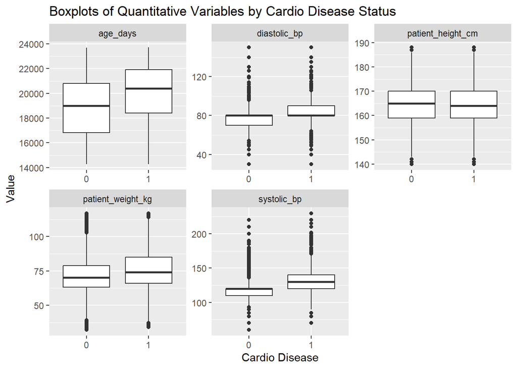

```r
# Сбор данных в "длинный" формат для использования в facet_wrap
long_data <- cleaned_data %>%
  pivot_longer(
    cols = c(age_days, patient_height_cm, patient_weight_kg, systolic_bp, diastolic_bp),
    names_to = "variable",
    values_to = "value"
  )

# Боксплот для всех количественных переменных
ggplot(long_data, aes(x = as.factor(has_cardio_disease), y = value)) +
  geom_boxplot() +
  facet_wrap(~variable, scales = "free") +
  labs(title = "Boxplots of Quantitative Variables by Cardio Disease Status", x = "Cardio Disease", y = "Value")
```

2. Наложите на боксплоты beeplots - задание со звёздочкой.

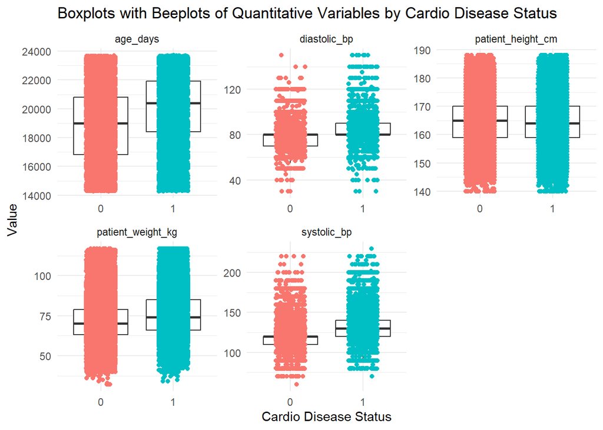

```r
# Боксплоты с наложенными beeplots для всех количественных переменных
ggplot(long_data, aes(x = as.factor(has_cardio_disease), y = value)) +
  geom_boxplot(outlier.shape = NA) +  # Скрыть выбросы на боксплоте
  geom_jitter(aes(color = as.factor(has_cardio_disease)), width = 0.2) +
  facet_wrap(~variable, scales = "free") +
  labs(title = "Boxplots with Beeplots of Quantitative Variables by Cardio Disease Status",
       x = "Cardio Disease Status",
       y = "Value") +
  theme_minimal() +
  theme(legend.position = "none")
```

3. Раскрасьте боксплоты с помощью библиотеки RColorBrewer.

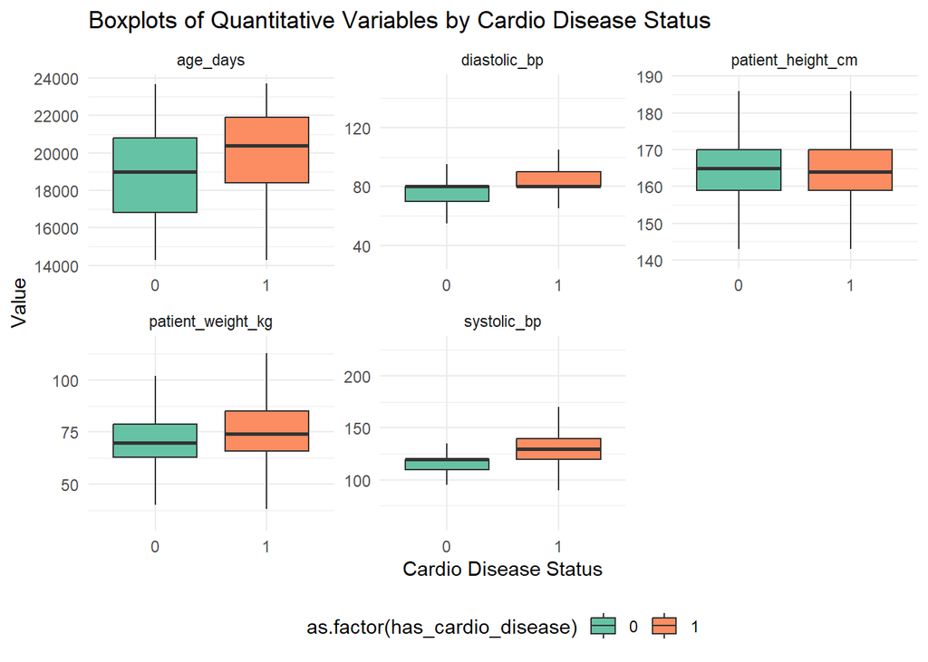

```r
library(RColorBrewer)

# Выбор цветовой палитры из RColorBrewer
palette <- brewer.pal(n = 3, name = "Set2")


# Боксплоты для всех количественных переменных с использованием выбранной палитры
ggplot(long_data, aes(x = as.factor(has_cardio_disease), y = value, fill = as.factor(has_cardio_disease))) +
  geom_boxplot(outlier.shape = NA) +  # Выбросы не отображаются
  scale_fill_manual(values = palette) +
  facet_wrap(~variable, scales = "free") +
  labs(title = "Boxplots of Quantitative Variables by Cardio Disease Status",
       x = "Cardio Disease Status",
       y = "Value") +
  theme_minimal() +
  theme(legend.position = "bottom")  # Позиция легенды
```

## Категориальные переменные

1. Сделайте подходящие визуализации категориальных переменных. Обоснуйте, почему выбрали именно этот тип.

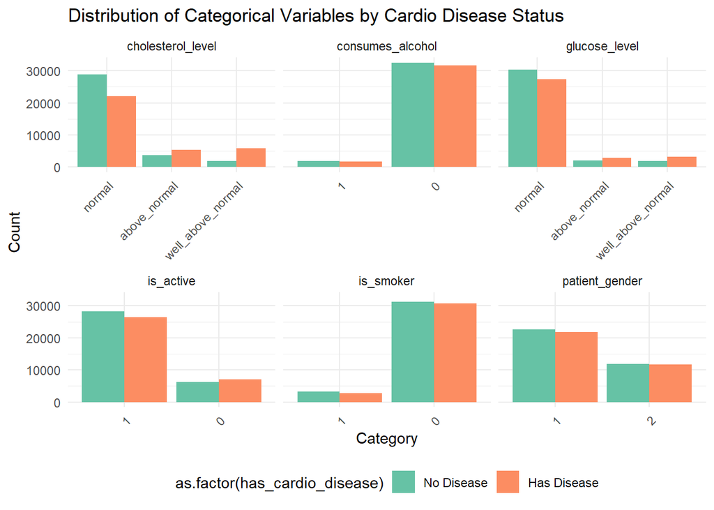

```r
# Преобразование данных в "длинный" формат для категориальных переменных
long_cat_data <- cleaned_data %>%
  pivot_longer(
    cols = c(patient_gender, cholesterol_level, glucose_level, is_smoker, consumes_alcohol, is_active),
    names_to = "category",
    values_to = "value"
  )%>%
  mutate(has_cardio_disease = recode(has_cardio_disease, `0` = "No Disease", `1` = "Has Disease"))


# Создание объединенного графика для категориальных переменных
ggplot(long_cat_data, aes(x = value, fill = as.factor(has_cardio_disease))) +
  geom_bar(position = "dodge") +
  facet_wrap(~category, scales = "free_x") +
  labs(title = "Distribution of Categorical Variables by Cardio Disease Status",
       x = "Category",
       y = "Count") +
  scale_fill_brewer(palette = "Set2") +
  theme_minimal() +
  theme(legend.position = "bottom", axis.text.x = element_text(angle = 45, hjust = 1))
```

Столбчатые диаграммы являются одним из наиболее эффективных способов визуализации категориальных данных. Этот тип диаграмм позволяет наглядно сравнить количество или долю наблюдений в различных категориях. В данном случае диаграммы позволяют сравнивать распределение категориальных переменных между двумя группами: с сердечно-сосудистыми заболеваниями и без них.

# Статистические оценки

## Проверка на нормальность

1. Оцените каждую переменную на соответствие нормальному распределению с помощью теста Шапиро-Уилка. Какие из переменных являются нормальными и как как вы это поняли?

*если p-значение теста больше выбранного уровня значимости (alpha = 0.05), то гипотеза о нормальности не отвергается.

Интерпретация:

*Если p-значение > 0.05, данные не противоречат предположению о нормальности распределения.* Если p-значение ≤ 0.05, гипотеза о нормальности отвергается, и данные, скорее всего, не распределены нормально.

```r
# Создание списка с количественными переменными
quantitative_vars <- c("age_days", "patient_height_cm", "patient_weight_kg", "systolic_bp", "diastolic_bp")

# Создание подвыборки, т.к. выборка слишком велика
sample_size <- min(5000, nrow(cleaned_data))
subsample <- cleaned_data %>% sample_n(sample_size)

# Тест Шапиро-Уилка на подвыборке
shapiro_results_subsample <- lapply(subsample[quantitative_vars], shapiro.test)

# Вывод результатов
shapiro_results_subsample
```

```
## $age_days
##
##  Shapiro-Wilk normality test
##
## data:  X[[i]]
## W = 0.96489, p-value < 2.2e-16
##
##
## $patient_height_cm
##
##  Shapiro-Wilk normality test
##
## data:  X[[i]]
## W = 0.99609, p-value = 2.892e-10
##
##
## $patient_weight_kg
##
##  Shapiro-Wilk normality test
##
## data:  X[[i]]
## W = 0.97759, p-value < 2.2e-16
##
##
## $systolic_bp
##
##  Shapiro-Wilk normality test
##
## data:  X[[i]]
## W = 0.91628, p-value < 2.2e-16
##
##
## $diastolic_bp
##
##  Shapiro-Wilk normality test
##
## data:  X[[i]]
## W = 0.88202, p-value < 2.2e-16
```

Выводы:

p-value для каждой переменной меньше, чем порог 0.05. Это означает, что нулевая гипотеза о нормальности распределения отвергается для всех переменных. Следовательно предполагается, что ни одна из рассмотренных переменных не распределена нормально.

В каждом случае значение статистики W меньше 1, что также указывает на отклонение от нормального распределения. Чем ближе значение W к 1, тем больше распределение данных приближается к нормальному. Однако даже для patient_height_cm, которая имеет значение W близкое к 1, p-value указывает на статистически значимое отклонение от нормальности, возможно, из-за большого размера выборки.

2. Постройте для каждой количественной переменной QQ-плот. Отличаются ли выводы от теста Шапиро-Уилка? Какой метод вы бы предпочли и почему?

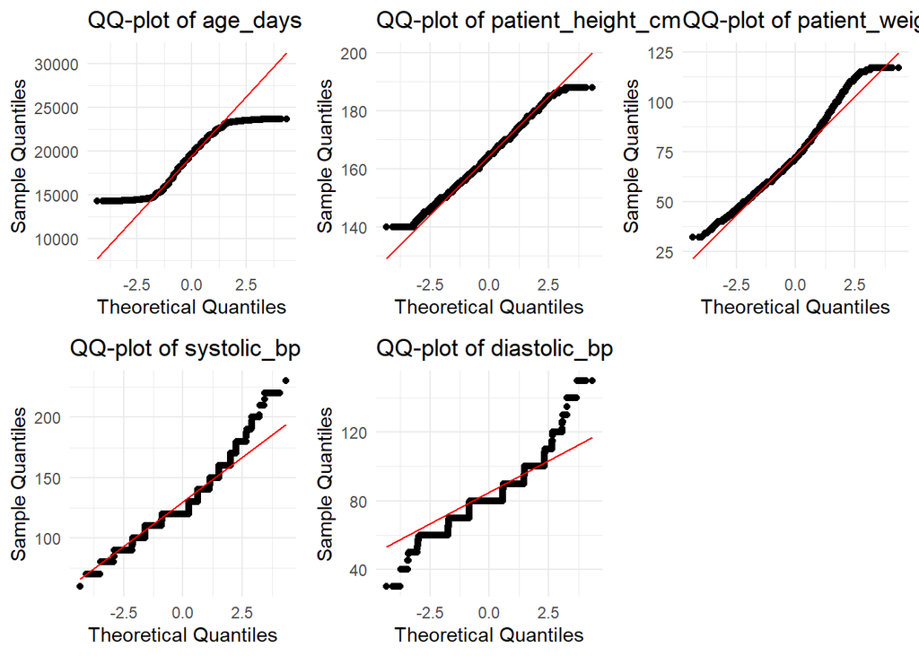

```r
library(ggpubr)

# Функция для создания QQ-плота для одной переменной
create_qq_plot <- function(data, variable_name) {
  qq_plot <- ggplot(data, aes(sample = .data[[variable_name]])) +
    stat_qq() +
    stat_qq_line(col = "red") +
    labs(title = paste("QQ-plot of", variable_name), x = "Theoretical Quantiles", y = "Sample Quantiles") +
    theme_minimal()
  return(qq_plot)
}

# Создание списка с QQ-плотами для всех количественных переменных
qq_plots <- lapply(quantitative_vars, function(var) create_qq_plot(cleaned_data, var))

# Отображение QQ-плотов
ggarrange(plotlist = qq_plots, ncol = 3, nrow = 2)
```

*Отличаются ли выводы от теста Шапиро-Уилка? Какой метод вы бы предпочли и почему?*

На основе QQ-плотов можно сделать следующие выводы:

*QQ-плот patient_height_cm: точки близки к прямой линии, но есть небольшое отклонение на концах. Это может указывать на лёгкое отклонение от нормального распределения, вероятно, из-за наличия выбросов или небольшой асимметрии.

*QQ-плот patient_weight_kg: похожая ситуация, как и с ростом — точки близки к прямой, но с небольшими отклонениями, указывающими на возможные выбросы.

*QQ-плот systolic_bp и diastolic_bp: отчётливо видны значительные отклонения от прямой линии, что указывает на отклонение от нормальности и наличие скошенности в данных.

Эти наблюдения согласуются с результатами теста Шапиро-Уилка, который показал, что ни одна из переменных не распределена нормально (p-value < 0.05).

*Какой метод предпочтительнее?*

Тест Шапиро-Уилка дает точный статистический вывод и позволяет формально проверить гипотезу о нормальности. Однако этот тест может быть чувствителен к большим размерам выборки, когда даже незначительные отклонения от нормальности могут привести к отвержению нулевой гипотезы.

QQ-плоты дают визуальное представление о распределении данных и могут быть более информативными для определения природы отклонения от нормальности. Они особенно полезны для выявления особенностей распределения, таких как тяжёлые хвосты или выбросы.

В идеале, следует использовать оба метода в комбинации: тест Шапиро-Уилка для получения формального статистического заключения и QQ-плоты для более детального визуального анализа распределения.

В данном случае предпочтительно использование QQ-плотов из-за большого размера выборки и из-за возможности увидеть потенциальные выбросы и тяжелые хвосты на QQ-плотах.

3. Ниже напишите, какие ещё методы проверки на нормальность вы знаете и какие у них есть ограничения.

*Визуальные методы: включают QQ-плоты, гистограммы и графики оценки плотности. Эти методы хороши для визуальной проверки нормальности, но они субъективны и могут быть недостаточны для формального доказательства.

Ограничения: - Субъективное интерпретирование. - Могут быть нечеткими при малых размерах выборки.

*Статистические тесты:

- Тест Колмогорова-Смирнова (K-S тест): этот тест сравнивает эмпирическую функцию распределения выборки с функцией распределения нормального закона. Однако он более чувствителен к отклонениям в центре распределения, чем на его хвостах, и может быть неэффективен при наличии выбросов.

Ограничения: - Не столь мощен при обнаружении отклонений на хвостах распределения. - Может быть восприимчив к большим размерам выборки.

- Тест Лиллиефорса (модификация K-S теста): этот тест — это модификация K-S теста, которая учитывает, что параметры нормального распределения оцениваются по данным.

Ограничения: - Меньшая мощность теста по сравнению с тестом Шапиро-Уилка.

*Тест Андерсона-Дарлинга: тест сравнивает эмпирическую функцию распределения с нормальной и акцентирует внимание на хвостах распределения, что делает его более чувствительным к выбросам.

Ограничения: - Может быть слишком строгим при больших выборках. - Может давать ложные срабатывания при наличии тяжёлых хвостов.

*Тест Д’Агостино и Пирсона (омега-квадрат тест): тест основан на комбинации критериев скошенности и эксцесса и проверяет отклонения от нормального распределения.

Ограничения: - Не рекомендуется для небольших выборок (менее 20 наблюдений). - Может быть менее мощным, чем тест Шапиро-Уилка.

*Тест Крамера-фон Мизеса: Этот тест аналогичен тесту Андерсона-Дарлинга, но менее чувствителен к отклонениям на хвостах распределения.

Ограничения: - Как и другие тесты, может быть восприимчив к большим размерам выборки.

Выбор метода проверки на нормальность должен основываться на размере выборки, важности точности тестирования и наличии выбросов. Наиболее корректно использовать комбинацию визуального анализа и формальных статистических тестов для более полной оценки нормальности распределения данных.

## Сравнение групп

1. Сравните группы (переменная **cardio**) по каждой переменной (как количественной, так и категориальной). Для каждой переменной выберите нужный критерий и кратко обоснуйте его выбор в комментариях.

Код сначала проверяет нормальность распределения количественных переменных в каждой группе. Затем для каждой переменной проводит соответствующий тест (t-тест или тест Манна-Уитни для количественных переменных, хи-квадрат или точный тест Фишера для категориальных) и сохраняет результаты.

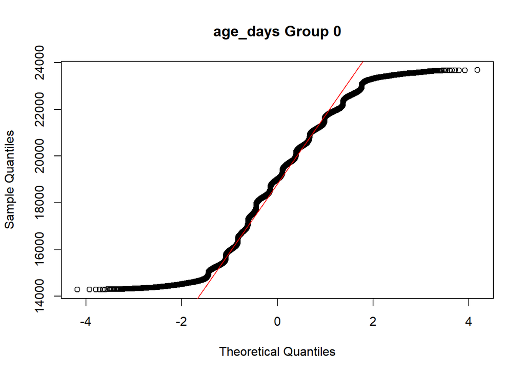

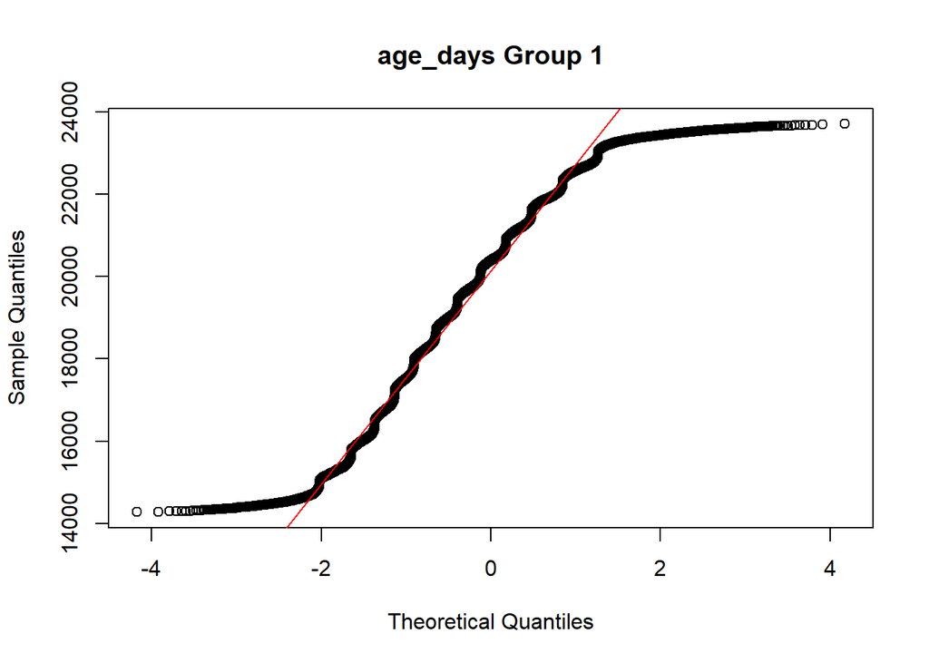

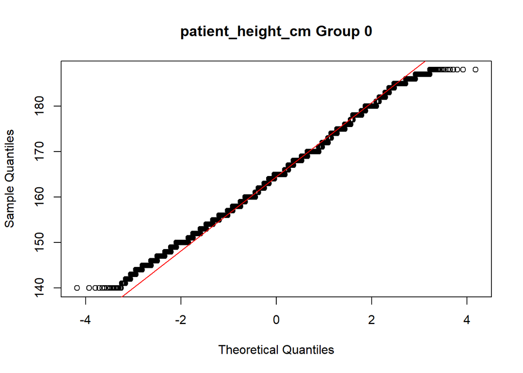

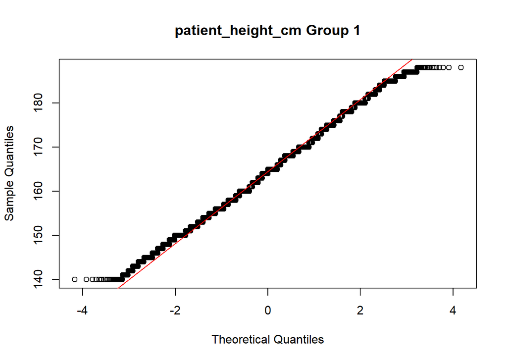

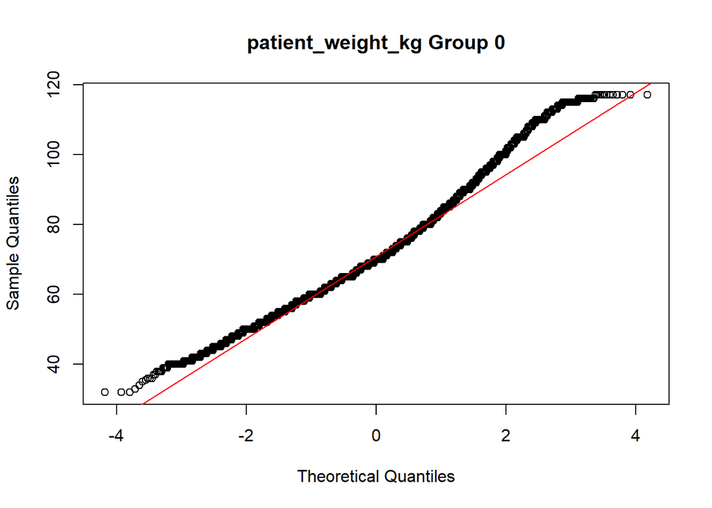

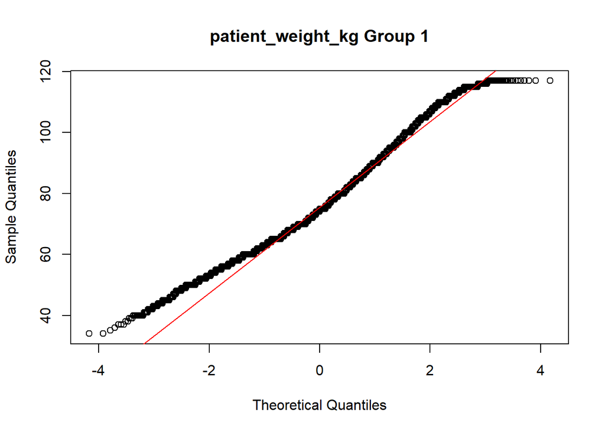

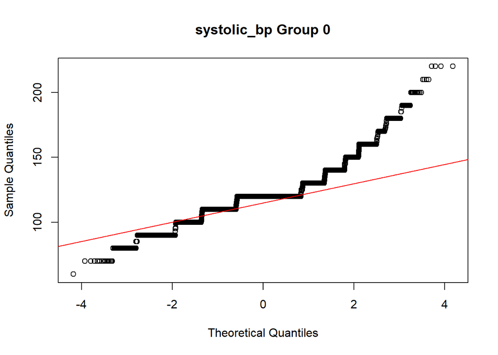

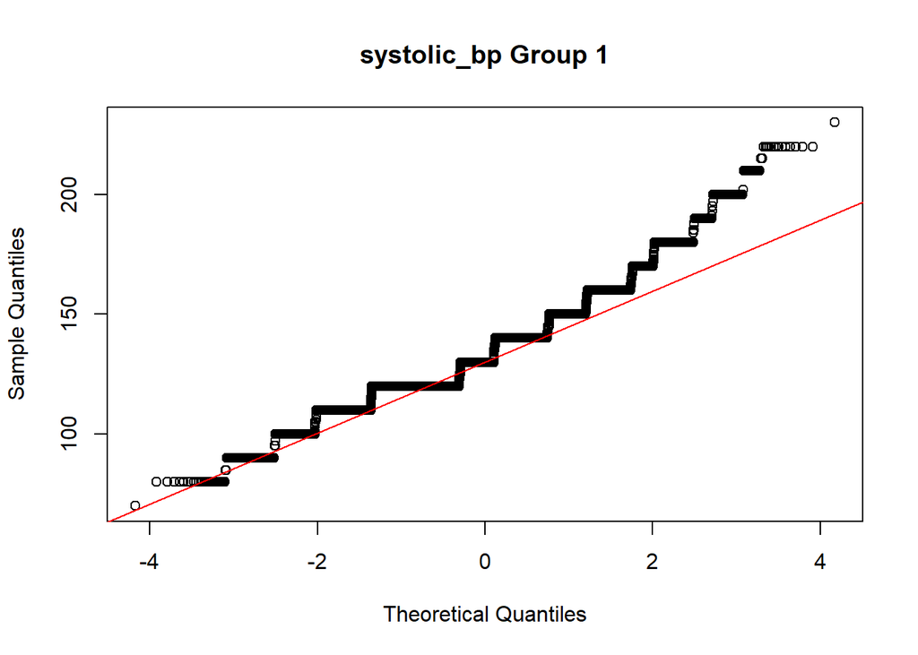

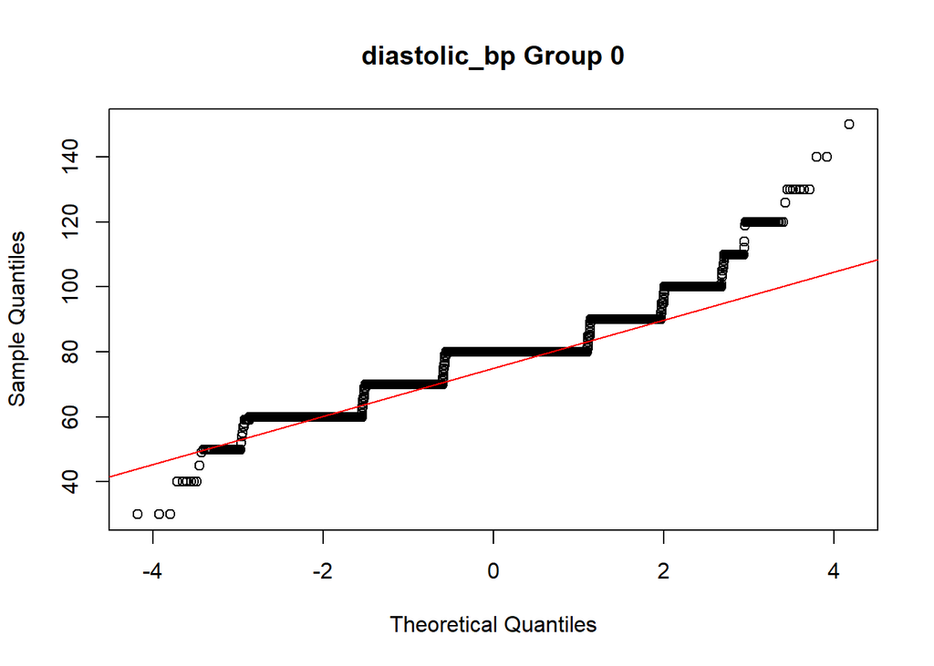

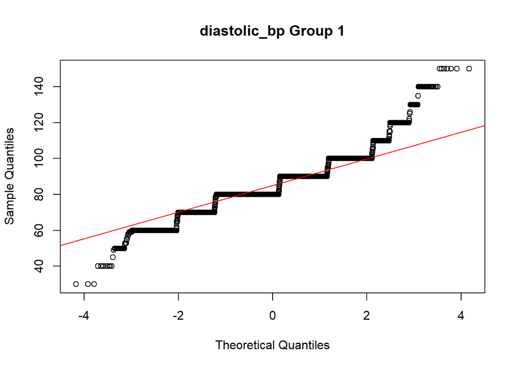

```r
#install.packages("nortest")
library(nortest)

# Функция для анализа количественных переменных
analyze_quantitative_variable <- function(data, variable) {
  # Визуальный анализ нормальности с помощью Q-Q графика
  qqnorm(data[[variable]][data$has_cardio_disease == '0'], main = paste(variable, "Group 0"))
  qqline(data[[variable]][data$has_cardio_disease == '0'], col = "red")
  qqnorm(data[[variable]][data$has_cardio_disease == '1'], main = paste(variable, "Group 1"))
  qqline(data[[variable]][data$has_cardio_disease == '1'], col = "red")

  # Тест Колмогорова-Смирнова
  ks_test_group1 <- lillie.test(data[[variable]][data$has_cardio_disease == '0'])
  ks_test_group2 <- lillie.test(data[[variable]][data$has_cardio_disease == '1'])

  if (ks_test_group1$p.value > 0.05 & ks_test_group2$p.value > 0.05) {
    # Если данные распределены нормально, используем t-тест
    test_result <- t.test(data[[variable]] ~ data$has_cardio_disease)
  } else {
    # Используем тест Манна-Уитни для не нормально распределенных данных
    test_result <- wilcox.test(data[[variable]] ~ data$has_cardio_disease)
  }

  return(test_result)
}

# Анализ количественных переменных
quant_vars <- c("age_days", "patient_height_cm", "patient_weight_kg", "systolic_bp", "diastolic_bp")
quant_results <- lapply(quant_vars, function(v) analyze_quantitative_variable(cleaned_data, v))
```

```r
# Функция для анализа категориальных переменных
analyze_categorical_variable <- function(data, variable) {
  # Тест хи-квадрат или точный тест Фишера
  tab <- table(data[[variable]], data$has_cardio_disease)
  if (min(tab) < 5) {
    # Используем точный тест Фишера при малых ожидаемых частотах
    test_result <- fisher.test(tab)
  } else {
    test_result <- chisq.test(tab)
  }

  return(test_result)
}
# Анализ категориальных переменных
cat_vars <- c("patient_gender", "cholesterol_level", "glucose_level", "is_smoker", "consumes_alcohol", "is_active")
cat_results <- lapply(cat_vars, function(v) analyze_categorical_variable(cleaned_data, v))

# Вывод результатов
list(Quantitative = quant_results, Categorical = cat_results)
```

```
## $Quantitative
## $Quantitative[[1]]
##
##  Wilcoxon rank sum test with continuity correction
##
## data:  data[[variable]] by data$has_cardio_disease
## W = 416629701, p-value < 2.2e-16
## alternative hypothesis: true location shift is not equal to 0
##
##
## $Quantitative[[2]]
##
##  Wilcoxon rank sum test with continuity correction
##
## data:  data[[variable]] by data$has_cardio_disease
## W = 585014293, p-value = 7.636e-05
## alternative hypothesis: true location shift is not equal to 0
##
##
## $Quantitative[[3]]
##
##  Wilcoxon rank sum test with continuity correction
##
## data:  data[[variable]] by data$has_cardio_disease
## W = 457709798, p-value < 2.2e-16
## alternative hypothesis: true location shift is not equal to 0
##
##
## $Quantitative[[4]]
##
##  Wilcoxon rank sum test with continuity correction
##
## data:  data[[variable]] by data$has_cardio_disease
## W = 287541603, p-value < 2.2e-16
## alternative hypothesis: true location shift is not equal to 0
##
##
## $Quantitative[[5]]
##
##  Wilcoxon rank sum test with continuity correction
```

[output cut: 39 more lines]

```
##
## $Categorical[[5]]
##
##  Pearson's Chi-squared test with Yates' continuity correction
##
## data:  tab
## X-squared = 5.1584, df = 1, p-value = 0.02313
##
##
## $Categorical[[6]]
##
##  Pearson's Chi-squared test with Yates' continuity correction
##
## data:  tab
## X-squared = 96.004, df = 1, p-value < 2.2e-16
```

# Далее идут **необязательные** дополнительные задания, которые могут принести вам дополнительные баллы в том числе в случае ошибок в предыдущих

## Корреляционный анализ

1. Создайте корреляционную матрицу с визуализацией и поправкой на множественные сравнения. Объясните, когда лучше использовать корреляционные матрицы и в чём минусы и плюсы корреляционных исследований.

*Когда лучше использовать корреляционные матрицы:*

*Эксплораторный анализ: корреляционные матрицы полезны для первичного анализа отношений между переменными.* Определение взаимосвязей: помогают выявить потенциальные взаимосвязи между переменными перед проведением более сложного анализа.

*Плюсы корреляционных исследований:*

*Простота понимания: корреляции легко интерпретировать.* Выявление взаимосвязей: помогают определить, есть ли связь между переменными.

*Минусы корреляционных исследований:*

*Отсутствие причинно-следственных связей: корреляция не означает причинность.* Влияние выбросов: выбросы могут сильно исказить результаты корреляции. *Ограничения в типах данных: корреляция Пирсона требует нормального распределения данных.

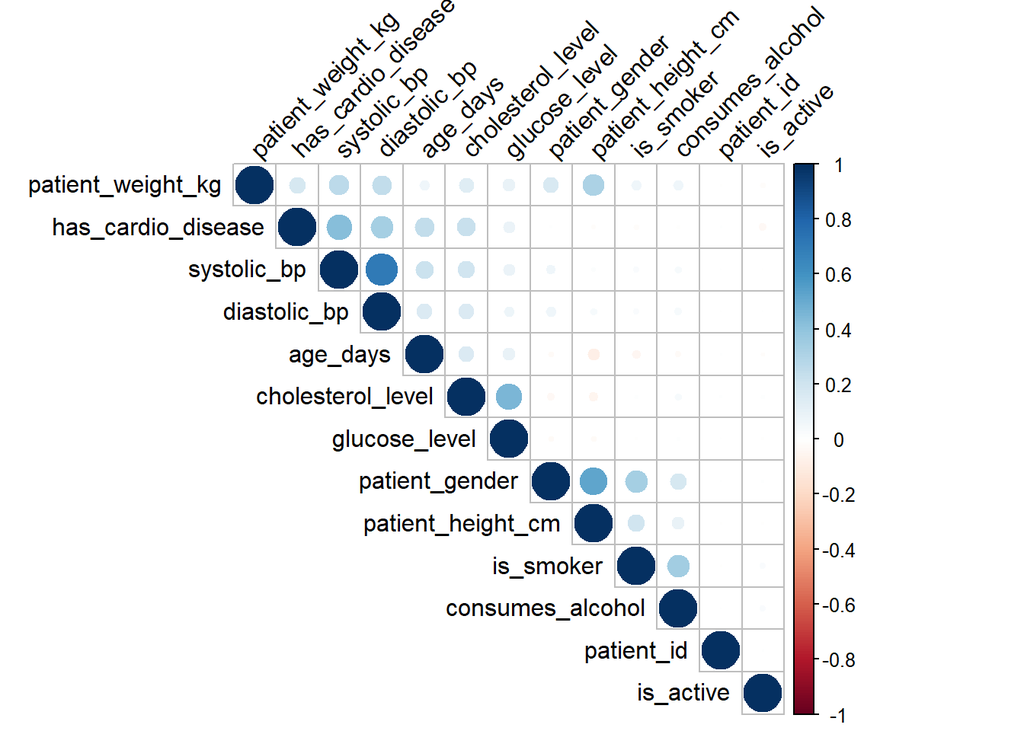

```r
# Конвертация категориальных переменных в числовые
cleaned_data$patient_gender <- as.numeric(factor(cleaned_data$patient_gender))
cleaned_data$cholesterol_level <- as.numeric(factor(cleaned_data$cholesterol_level, levels = c("normal", "above_normal", "well_above_normal")))
cleaned_data$glucose_level <- as.numeric(factor(cleaned_data$glucose_level, levels = c("normal", "above_normal", "well_above_normal")))
cleaned_data$is_smoker <- as.numeric(factor(cleaned_data$is_smoker))
cleaned_data$consumes_alcohol <- as.numeric(factor(cleaned_data$consumes_alcohol))
cleaned_data$is_active <- as.numeric(factor(cleaned_data$is_active))
cleaned_data$has_cardio_disease <- as.numeric(factor(cleaned_data$has_cardio_disease))

# Вычисление корреляционной матрицы
cor_matrix <- cor(cleaned_data, use = "complete.obs")

# Визуализация корреляционной матрицы
corrplot(cor_matrix, method = "circle", type = "upper", order = "hclust",
         tl.col = "black", tl.srt = 45)
```

```r
# Поправка на множественные сравнения
p_values <- cor.mtest(cleaned_data)$p
p_adjusted <- p.adjust(p_values, method = "bonferroni")

# Вывод скорректированных значений p
print(p_adjusted)
```

```
##   [1]  0.000000e+00  1.000000e+00  1.000000e+00  1.000000e+00  1.000000e+00
##   [6]  1.000000e+00  1.000000e+00  1.000000e+00  1.000000e+00  1.000000e+00
##  [11]  1.000000e+00  1.000000e+00  1.000000e+00  1.000000e+00  0.000000e+00
##  [16]  1.697878e-06 3.509531e-108  2.594832e-62  0.000000e+00  0.000000e+00
##  [21]  0.000000e+00 2.637230e-145  3.437027e-32  3.793224e-11  8.133911e-01
##  [26]  0.000000e+00  1.000000e+00  1.697878e-06  0.000000e+00  0.000000e+00
##  [31]  0.000000e+00  1.632799e-53  2.941310e-66  1.192600e-19  3.232580e-06
##  [36]  0.000000e+00  0.000000e+00  1.000000e+00  1.000000e+00  1.000000e+00
##  [41] 3.509531e-108  0.000000e+00  0.000000e+00  0.000000e+00  1.599076e-01
##  [46]  2.062129e-14  2.625767e-50  1.631151e-06  0.000000e+00 1.286922e-139
##  [51]  1.000000e+00  4.475588e-03  1.000000e+00  2.594832e-62  0.000000e+00
##  [56]  0.000000e+00  0.000000e+00  0.000000e+00  0.000000e+00 2.447693e-284
##  [61] 1.206125e-144  2.055781e-63  4.984651e-67  1.445820e-03  0.000000e+00
##  [66]  1.000000e+00  0.000000e+00  1.632799e-53  1.599076e-01  0.000000e+00
##  [71]  0.000000e+00  0.000000e+00  0.000000e+00 7.706852e-119  1.719909e-09
```

[output cut: 19 more lines]

## Моделирование

1. Постройте регрессионную модель для переменной **cardio**. Опишите процесс построения

Процесс построения прописан в комментариях к коду:

```r
# Установка seed для воспроизводимости результатов
set.seed(309)

# Преобразование значений в переменной has_cardio_disease
cleaned_data$has_cardio_disease <- cleaned_data$has_cardio_disease - 1

# Разделение данных на обучающую и тестовую выборки
indexes <- sample(1:nrow(cleaned_data), size = 0.7 * nrow(cleaned_data))
train_data <- cleaned_data[indexes, ]
test_data <- cleaned_data[-indexes, ]

# Построение модели логистической регрессии
model <- glm(has_cardio_disease ~ ., data = train_data, family = binomial())

# Оценка модели на тестовой выборке
predictions <- predict(model, newdata = test_data, type = "response")
predicted_classes <- ifelse(predictions > 0.5, 1, 0)

# Создание матрицы ошибок для оценки точности
table(predicted_classes, test_data$has_cardio_disease)
```

```
##
## predicted_classes    0    1
##                 0 8121 3302
##                 1 2260 6663
```

```r
# Интерпретация результатов
summary(model)
```

```
##
## Call:
## glm(formula = has_cardio_disease ~ ., family = binomial(), data = train_data)
##
## Coefficients:
##                     Estimate Std. Error z value Pr(>|z|)
## (Intercept)       -1.058e+01  3.036e-01 -34.834  < 2e-16 ***
## patient_id         1.179e-07  3.645e-07   0.324 0.746313
## age_days           1.412e-04  4.480e-06  31.518  < 2e-16 ***
## patient_gender    -7.167e-04  2.683e-02  -0.027 0.978688
## patient_height_cm -5.554e-03  1.685e-03  -3.297 0.000977 ***
## patient_weight_kg  1.193e-02  8.946e-04  13.340  < 2e-16 ***
## systolic_bp        5.377e-02  1.064e-03  50.536  < 2e-16 ***
## diastolic_bp       1.747e-02  1.677e-03  10.418  < 2e-16 ***
## cholesterol_level  4.944e-01  1.888e-02  26.191  < 2e-16 ***
## glucose_level     -1.304e-01  2.143e-02  -6.082 1.19e-09 ***
## is_smoker         -1.830e-01  4.211e-02  -4.346 1.39e-05 ***
## consumes_alcohol  -1.979e-01  5.124e-02  -3.862 0.000112 ***
## is_active         -2.480e-01  2.636e-02  -9.407  < 2e-16 ***
## ---
## Signif. codes:  0 '***' 0.001 '**' 0.01 '*' 0.05 '.' 0.1 ' ' 1
##
## (Dispersion parameter for binomial family taken to be 1)
##
##     Null deviance: 65799  on 47468  degrees of freedom
## Residual deviance: 53199  on 47456  degrees of freedom
##   (9 пропущенных наблюдений удалены)
## AIC: 53225
##
## Number of Fisher Scoring iterations: 4
```

*Анализ коэффициентов модели:*

(Intercept), age_days, patient_height_cm, patient_weight_kg, systolic_bp, diastolic_bp, cholesterol_level, glucose_level, is_smoker, consumes_alcohol, is_active показывают влияние соответствующих переменных на логарифм шансов наличия сердечно-сосудистого заболевания. Значения Estimate отражают силу и направление этого влияния. Signif. codes: Звездочки рядом с коэффициентами показывают уровень значимости этих коэффициентов. Например, три звездочки (***) указывают на очень высокий уровень значимости (p < 0.001).

*Выводы*

Значимые переменные: в модели наиболее значимыми являются возраст (age_days), рост (patient_height_cm), вес (patient_weight_kg), систолическое (systolic_bp) и диастолическое (diastolic_bp) артериальное давление, уровень холестерина (cholesterol_level), уровень глюкозы (glucose_level), курение (is_smoker), употребление алкоголя (consumes_alcohol) и физическая активность (is_active). Эти переменные оказывают значительное влияние на вероятность наличия сердечно-сосудистых заболеваний.

Переменная patient_gender не показала статистической значимости в данной модели.